[figure not shown]

# NS Merger Training Workshop

### Centro Residenziale Universitario di Bertinoro, 12-16 November 2018

https://nsmergerworkshop.wordpress.com/

# 1. LIGO/Virgo probability sky maps

Probability sky maps associated with a gravitational-wave signal detected by the Advanced LIGO and Virgo are given as all-sky images stored in the [HEALPix](http://healpix.sourceforge.net/) (Hierarchical Equal Area isoLatitude Pixelisation) projection. The sphere is hierarchically tessellated into curvilinear quadrilaterals; the resolution of the tessellation can be increased by the division of each pixel into four new ones.  
**The lowest resolution partition is comprised of twelve base pixels.** **The pixel position on the sky is uniquely specified by the index in the array and the array’s length.** The resolution of the grid is expressed by the parameter N<sub>side</sub>, and the total number of pixels equal to **N<sub>pixs</sub> = 12 x N<sub>side</sub><sup>2</sup>**. In such context, the value stored at each pixel represents the probability that the gravitational-wave source is located within that pixel (see [LIGO-Virgo EM Follow-Up Tutorial](http://nbviewer.jupyter.org/github/lpsinger/ligo-virgo-emfollowup-tutorial/blob/master/ligo-virgo-emfollowup-tutorial.ipynb)).

```python
from IPython.display import Image
from IPython.display import display
display(Image(url='https://healpix.jpl.nasa.gov/images/healpixGridRefinement.jpg'))
```

[figure not shown]

**FIG.1.** It shows the partitioning of a sphere at progressively higher resolutions, from left to right. The green sphere represents the lowest resolution possible with the HEALPix base partitioning of the sphere surface into 12 equal sized pixels. The yellow sphere has a HEALPix grid of 48 pixels, the red sphere has 192 pixels, and the blue sphere has a grid of 768 pixels (more information [here](https://healpix.jpl.nasa.gov/)).

# 2. Healpy: reading and plotting

## Setting up the Python Environment

The following packages are needed for working with this tutorial: Astropy, Healpy, and Numpy. We will also utilize Matplotlib, Scipy, and Astroquery. All of these packages can be installed using Pip.

```python
import astropy
import numpy
import healpy
import matplotlib
```

# **Final skymap of GW150914**

### 1. Download LALInference skymap from the Gravitational Wave Open Science Center

```python
from  astropy.utils.data import download_file
final_skymap_gw150914 = download_file(remote_url= "https://www.gw-openscience.org/GW150914data/P1500227/LALInference_skymap.fits.gz",cache = True)
```

### 2. Reading the skymap with Healpy

```python
import healpy as hp

prob = hp.read_map(filename=final_skymap_gw150914, verbose = False)

# prob is the probability that the gw source is within that pixel
# by default  "read_map" method reads the first column
```

### 3. Skymap Plot

```
0.0 180.0 -180.0 180.0
The interval between parallels is 30 deg -0.00'.
The interval between meridians is 30 deg -0.00'.
```

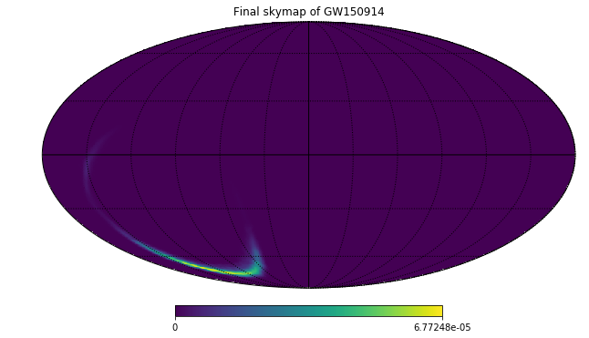

```python
from matplotlib import pyplot as plt

hp.mollview(prob,title ="Final skymap of GW150914", )

# add grid
hp.graticule()
plt.show()
```

### 4. Header

```python
prob, header = hp.read_map(filename=final_skymap_gw150914, h=True, verbose=False)
print(header)

header = dict(header)
print(type(header))

nside = header["NSIDE"]
print ("Nside is:",nside)
```

```
[('XTENSION', 'BINTABLE'), ('BITPIX', 8), ('NAXIS', 2), ('NAXIS1', 4096), ('NAXIS2', 3072), ('PCOUNT', 0), ('GCOUNT', 1), ('TFIELDS', 1), ('TTYPE1', 'PROB'), ('TFORM1', '1024E'), ('TUNIT1', 'pix-1'), ('PIXTYPE', 'HEALPIX'), ('ORDERING', 'NESTED'), ('COORDSYS', 'C'), ('EXTNAME', 'xtension'), ('NSIDE'…
<class 'dict'>
Nside is: 512
```

### 5. Npix and Nside

```python
Npix = 12* nside**2
print("the number of pixels is:",Npix)

Npix = hp.get_map_size(prob)
print("the number of pixels is:",Npix)

Npix = len(prob)
print("the number of pixels is:",Npix)

nside = hp.npix2nside(npix=Npix)
print("Nside is:", nside)
```

```
the number of pixels is: 3145728
the number of pixels is: 3145728
the number of pixels is: 3145728
Nside is: 512
```

### 6a. Finding the maximum probability pixel on the sky

**The pixel position on the sky is uniquely specified by the index in the array (list) and the length of the array (list).**

```python
import numpy as np
# np.argmax --> return the index  of the maximum pixel
ipix_max =  np.argmax(prob)
print("the index of the highest pixel is", ipix_max)

# probability value inside the maximum pixel

max_prob = prob[ipix_max]
print ("the value of the probability of the maximum pixel is",max_prob)
```

```
the index of the highest pixel is 3048817
the value of the probability of the maximum pixel is 6.780870899092406e-05
```

```python
# basic example

a = [1,2,3,10]

m = np.argmax(a)
m

a[m]
```

```
10
```

### 6b. Sky position of the maximum probability pixel

The [`pix2ang`](http://healpy.readthedocs.org/en/latest/generated/healpy.pixelfunc.pix2ang.html) method converts **from pixel index to spherical polar coordinates**; the function [`ang2pix`](http://healpy.readthedocs.org/en/latest/generated/healpy.pixelfunc.ang2pix.html) does the reverse. Both `pix2ang` and `ang2pix` take, as their first argument, `nside`.

Healpy uses spherical coordinates $(\theta, \phi)$ with $\theta \in [0, \pi]$ being the colatitude from the north celestial pole in radians, and $\phi \in [0, 2\pi]$ being the right ascension in radians.

Then use Numpy's [`rad2deg`](http://docs.scipy.org/doc/numpy/reference/generated/numpy.rad2deg.html) function to convert these to right ascension and declination in degrees.

```python
# theta and phi: pix2ang
theta, phi = hp.pix2ang(nside, ipix_max)

# ra and dec in degrees: rad2deg
ra =  np.rad2deg(phi)
dec = np.rad2deg(0.5*np.pi-theta)
ra, dec
```

```
(134.79545454545453, -69.79389373110558)
```

### 7. Excercise

Find which pixel contains the sky position of **NGC 4993** and the probability inside it. NGC 4993 is the host galaxy of the BNS merger event, GW170817. Download from [Gravitational Wave Open Science Center](https://www.gw-openscience.org/about/) the final skymap - LALInference. Coordinates of NGC 4993: ra, dec = 197.45, -23.38

```python
from  astropy.utils.data import download_file
final_skymap_gw170817 = download_file(remote_url= "https://dcc.ligo.org/public/0146/G1701985/001/LALInference_v2.fits.gz",cache = True)

prob, header = hp.read_map(filename=final_skymap_gw170817, h = True, verbose = True)
print(header)

# Converting ra and dec to radians: theta and phi
ra, dec = 197.45, -23.38

phi = np.deg2rad(ra)
theta = 0.5*np.pi-np.deg2rad(dec)

nside =1024

ipix  = hp.ang2pix(nside,theta,phi)
print("the pixel which contains the sky position of NGC 4993 is", ipix)

pixel_prob = prob[ipix]

print("the probability contains in the pixel is:", pixel_prob)
```

```
NSIDE = 1024
ORDERING = NESTED in fits file
INDXSCHM = IMPLICIT
Ordering converted to RING
[('XTENSION', 'BINTABLE'), ('BITPIX', 8), ('NAXIS', 2), ('NAXIS1', 32), ('NAXIS2', 12582912), ('PCOUNT', 0), ('GCOUNT', 1), ('TFIELDS', 4), ('TTYPE1', 'PROB'), ('TFORM1', 'D'), ('TUNIT1', 'pix-1'), ('TTYPE2', 'DISTMU'), ('TFORM2', 'D'), ('TUNIT2', 'Mpc'), ('TTYPE3', 'DISTSIGMA'), ('TFORM3', 'D'), ('…
the pixel which contains the sky position of NGC 4993 is 8790214
the probability contains in the pixel is: 0.0002937359750744584
```

```python
from IPython.display import Image
from IPython.display import display

display(Image(url='http://ligo.org/science/Publication-GW170817MMA/images/BNS.png',width=600, height=500))
```

[figure not shown]

**Fig.1.** shows an artist's illustration of two merging neutron stars. The narrow beams represent the gamma-ray burst while the rippling spacetime grid indicates the isotropic gravitational waves that characterize the merger. Swirling clouds of material ejected from the merging stars are a possible source of the light that was seen at lower energies.

### 8. Nested and Ring Ordering

https://prezi.com/ewuwfvbxhggb/gravitational-wave-skymap/?utm_campaign=share&utm_medium=copy

### 9. Probability contained within a circle or box on the sky

How do we find the probability that the source is contained within a circle on the sky? First we find the pixels that are contained within the circle using [`query_disc`](https://healpy.readthedocs.io/en/latest/generated/healpy.query_disc.html). Note that `query_disc` takes as its arguments the Cartesian coordinates of the center of the circle, and its radius in radians.

Then, we sum the values of the HEALPix image array contained at those pixels.

```python
# RA, Dec, and radius of circle in degrees
ra, dec = 197.45, -23.38

radius = 3

# Spherical polar coordinates and radius of circle in radians

theta = 0.5*np.pi-np.deg2rad(dec)
phi = np.deg2rad(ra)
radius = np.deg2rad(radius)

# Cartesian coordinates of center of circle: hp.ang2vec
xyz = hp.ang2vec(theta, phi)

# Array of indices of pixels inside circle
ipix_disc = hp.query_disc(nside, xyz, radius)

len(ipix_disc)

# Integrated Probability within circle

prob_disk = prob[ipix_disc].sum()

print("The integrated probability inside the disk is", prob_disk )
```

```
The integrated probability inside the disk is 0.49408559945116554
```

```python
# Vertices of polygon
xyz = [[-0.69601758, -0.41315628, -0.58724902],
       [-0.68590811, -0.40679797, -0.60336181],
       [-0.69106913, -0.39820114, -0.60320752],
       [-0.7011786 , -0.40455945, -0.58709473]]

# Array of indices of pixels inside polygon
ipix_poly = hp.query_polygon(nside, xyz)

# Probability that source is within polygon
prob[ipix_poly].sum()
```

```
1.0514530649244093e-52
```

https://github.com/ggreco77/GWsky/blob/master/GWsky/lvc_skymap.py

### 10. 3D skymap

Now, because we are working with a 3D skymap, we will read the distance information; **DISTMEAN** is the posterior mean distance in Mpc and **DISTSTD** is the posterior standard deviation of the distance in Mpc.

```python
header
header = dict(header)

dist_mean = header["DISTMEAN"]
dist_std = header["DISTSTD"]

print ("the posterior mean distance of GW170817 is:", dist_mean, "Mpc" )
print ("the posterior StD distance of GW170817 is:", dist_std, "Mpc" )
```

```
the posterior mean distance of GW170817 is: 38.58938617448738 Mpc
the posterior StD distance of GW170817 is: 6.996864447652665 Mpc
```

### Conditional Distance Distribution along a Line of Sight

Next, let us calculate the conditional distance distribution along a given line of sight. In other words, this is the probability per unit distance under the assumption that the source is in a given direction.

Now, we plug everyting into the ansatz distribution. The probability that a source is within pixel $i$ and at a distance between $r$ and $r + dr$ is: \begin{equation*} P(r, \vec{n}_i) dr = \rho_i \frac{\hat{N}_i}{\sqrt{2\pi}\hat{\sigma}_i} \text{exp} \left[-\frac{(r-\hat{\mu}_i)^2}{2\hat{\sigma}_i^2} \right] r^2 dr \end{equation*}

[Supplement: Going the Distance: Mapping Host Galaxies of LIGO and Virgo Sources in Three Dimensions Using Local Cosmography and Targeted Follow-up](https://arxiv.org/pdf/1605.04242.pdf)

```
NSIDE = 1024
ORDERING = NESTED in fits file
INDXSCHM = IMPLICIT
Ordering converted to RING
Ordering converted to RING
Ordering converted to RING
```

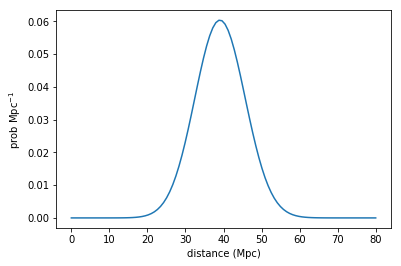

```python
#We first lay out a grid in distance along that line of sight.
r = np.linspace(0,80,100) # Returns 100 evenly spaced numbers between 0 and 80

from scipy.stats import norm # probability functions

distmu, distsigma, distnorm = hp.read_map(final_skymap_gw170817, field=[1,2,3])

dp_dr = r**2 * distnorm[ipix] * norm(distmu[ipix], distsigma[ipix]).pdf(r)

plt.plot(r, dp_dr)
plt.xlabel('distance (Mpc)')
plt.ylabel('prob Mpc$^{-1}$')
plt.show()
```

[GRAWITA follow-up of GW150914 and GW151226](https://arxiv.org/pdf/1710.05915.pdf)

# HANDS-on Section

### Degrating Sky map resolution

```python
# degrading the resolution of the skymap from NSIDE=1024 to NSIDE=512
# see https://dcc.ligo.org/DocDB/0149/G1800186/002/healpix-multiresolution.pdf

import numpy as np
import healpy as hp
from  astropy.utils.data import download_file
gw170814_final = download_file(remote_url= "https://dcc.ligo.org/public/0145/T1700453/001/LALInference_v1.fits.gz",cache = True)


prob = hp.read_map(gw170814_final, nest=True)

#hp.pixelfunc.ud_grade()
# WITH power=-2 keeps the sum of the map invariant
# https://healpy.readthedocs.io/en/latest/generated/healpy.pixelfunc.ud_grade.html
prob_512 = hp.pixelfunc.ud_grade(map_in=prob, nside_out=512,order_in='NESTED',
                                 order_out='NESTED', power=-2)

#https://healpy.readthedocs.io/en/latest/search.html?q=write_map&check_keywords=yes&area=default
hp.write_map('GW170814_fianl_512.fits.gz',prob_512, nest=True, coord ='C')
```

```
NSIDE = 1024
ORDERING = NESTED in fits file
INDXSCHM = IMPLICIT
```

### Degrade the resolution of the all skymaps of GW170817 (N<sub>side</sub> = 512) published so far

**1. Localized the ONLINE TRACK-LIKE NEUTRINO CANDIDATE reported in the [GCN CIRCULAR 21508](https://gcn.gsfc.nasa.gov/other/G298048.gcn3) with the bayestar skymaps with Virgo and without Virgo. Finally localize them within the more accurated localization issued so far.**

```python
from IPython.display import Image
from IPython.display import display
display(Image(url='https://github.com/ggreco77/Electromagnetic-follow-up-of-gravitational-wave-events/blob/master/ask.gif?raw=true'))
```

[figure not shown]

**2. Localized *the LIGO/Virgo G298048: Potential optical counterpart discovered by Swope telescope* and reported in the [GCN CIRCULAR 21529](https://gcn.gsfc.nasa.gov/other/G298048.gcn3) with the bayestar skymaps with Virgo and without Virgo. Finally localize it within the more accurated localization issued so far.**

```python
display(Image(url='https://github.com/ggreco77/Electromagnetic-follow-up-of-gravitational-wave-events/blob/master/pinpoint.gif?raw=true'))
```

[figure not shown]

### Degrade the resolution of the all skymaps of GW170814 (N<sub>side</sub> = 512) published so far

**5. Localize the source ATLAS17aeu reported during the [EM-followup of GW170104](https://gcn.gsfc.nasa.gov/other/G268556.gcn3) and plot the conditional distance distibution along the line of sight.**

**6. Managing a FoV sequence in GWsky: GW150914**

#### VST Observation of GW150914

[GRAWITA: VLT Survey Telescope observations of the gravitational wave sources GW150914 and GW151226](https://arxiv.org/pdf/1710.05915.pdf)

| pointings | RA[deg] | DEC[deg] |
| --- | --- | --- |
| p<sub>1</sub> | 58.208846 | -56.949515 |
| p<sub>2</sub> | 60.652964 | -59.855304 |
| p<sub>3</sub> | 68.948300 | -64.802918 |
| p<sub>4</sub> | 74.729746 | -66.793713 |
| p<sub>5</sub> | 82.166543 | -67.952724 |
| p<sub>6</sub> | 91.163807 | -71.180392 |
| p<sub>7</sub> | 100.348601 | -71.180473 |
| p<sub>8</sub> | 118.562044 | -71.090518 |
| p<sub>9</sub> | 122.909379 | -67.971038 |
| p<sub>10</sub> | 131.090822 | -67.972011 |

**Table 1** VST observation of GW150914, see https://www.grawita.inaf.it/highlights/

**7. Tile the initial skymaps of the evented reported so far requiring an airmass < 2.5 at the time of first the observation for i) Paranal Observatory ii) your observatory**

**8. Tile the initial skymaps of GW151216 as shown in the interactive skymap [here](https://www.grawita.inaf.it/highlights/). Adding new tiles in East and Weast directions using the "no show" button in Starting FoV.**

# Managing a FoV sequence in GWsky: GW170814

Getting the integrated probability of a FoV sequence when the skymap is updated. GWsky generates a file named *GWsky_pointing.txt*: **RA[deg]**, **DEC[deg]**, **probability**, **skymap name**

```python
display(Image(url='https://github.com/ggreco77/Electromagnetic-follow-up-of-gravitational-wave-events/blob/master/first_tiling.gif?raw=true'))
display(Image(url='https://github.com/ggreco77/Electromagnetic-follow-up-of-gravitational-wave-events/blob/master/second_tiling.gif?raw=true'))
display(Image(url='https://github.com/ggreco77/Electromagnetic-follow-up-of-gravitational-wave-events/blob/master/compare.gif?raw=true'))
```

[figure not shown]

Shift the sequence according with the shift the the update localization and press the botton **accept** to get the integrated probability in the **GWsky_pointing.txt**

```python
display(Image(url='https://github.com/ggreco77/Electromagnetic-follow-up-of-gravitational-wave-events/blob/master/shift.gif?raw=true'))
```

[figure not shown]

```python
from IPython.display import HTML

HTML('''<script>
code_show=true;
function code_toggle() {
 if (code_show){
 $('div.input').hide();
 } else {
 $('div.input').show();
 }
 code_show = !code_show
}
$( document ).ready(code_toggle);
</script>
<form action="javascript:code_toggle()"><input type="submit" value="Click here to toggle on/off the raw code."></form>''')
```